# Homework 1: SML Concepts and Applications

Author

Name ______________________Course_________

# Instructions

1. Copy the questions to a new document of your choice.
2. Answer each question as best you can.
3. If code is required, show your code. Be sure to show and interpret your results.
4. If work by hand is required, you may take a picture of your work and include/embed in your document or upload as an attachment. Be sure to label the question and include the question in the document.
5. Convert your document to an HTML or PDF document and submit on Canvas by the due date for your section.
6. STAT 427 students may complete the STAT 427 questions for credit.

## 0.1 Flexible or Inflexible (3 points)

For each part, indicate whether we would generally expect the performance of a flexible statistical learning method to be better or worse than an inflexible method. **Justify your answer**.

- The sample size $n$ is extremely large, and the number of predictors $p$ is small.
- The number of predictors $p$ is extremely large, and the number of observations $n$ is small.
- The relationship between the predictors and response is highly non-linear.
- The variance of the error terms is extremely high.

*Possible Solutions*

1. A flexible method is better. With only a few predictors, we can experiment with a wider set of models to obtain a better fit. A large sample will help reduce the bias.
2. A flexible method is worse. It will involve too many parameters causing high variance and unstable estimates, especially for a small sample. A flexible method would overfit a small number of observations.
3. A flexible method is better. Too many restrictions will allow only a few possible types of trends which may not capture the true nonlinear relationship. More degrees of freedom will yield a better fit.
4. A flexible method is worse. A high error variance coupled with a high degree of flexibility will result in a high variance of estimates and unreliable conclusions.

## 0.2 Potential Applications of SML (2 points)

Identify some examples of potential real-life applications for statistical learning. In each example, describe the response and the predictors and state the goal - inference or prediction.

- Describe two real-life applications in which classification might be useful.
- Describe two real-life applications in which regression might be useful.

## 0.3 Classification or Regression? (3 points)

Explain whether each scenario is a classification or regression problem, and indicate whether we are most interested in inference or prediction. Finally, provide $n$ and $p$.

- We collect a set of data on the top 300 publicly-traded firms in the US. For each firm we record profit, number of employees, industry, average stock price over the last year, and the CEO salary. We are interested in understanding which factors affect CEO salary.
- We are considering launching a new product and wish to know whether it will be a success or a failure. We collect data on 30 similar products that were previously launched. For each product we have recorded whether it was a success or failure, price charged for the product, marketing budget, competition price, and eight other variables.
- We are interested in estimating future % changes in the US dollar in relation to the weekly changes in the world stock markets. Hence we collect weekly data for all of 2015. For each week we record the % change in the dollar, the % change in the British market, the % change in the Japanese market, and % change in the German market.

*Possible Solutions*

1. Regression, $n = 300$ companies, $p = 4$ explanatory variables plus intercept. Inference as we are interested in what variables are important to the CEO salary.
2. Classification, $n = 30$ products, $p = 11$ predictors. Prediction success or failure.
3. Regression, $n = 52$ weeks $p = 3$ predictors plus intercept. Prediction as we are primarily interested in the quantitative value of response variable

## 0.4 Bias Variance Trade Off (3 points)

State True or False and then justify why the following are true or false in a single sentence.

- Increasing degrees of freedom to be large enough will always reduce Mean Squared Error to 0.
- Reducing bias is more important than reducing variance as a predicted value closer to the true value is always a better solution for your model.
- Choosing 50% of the data for training data always provides the best balance between a good fit for the model and an accurate predicted MSE.

*Possible Solutions*

1. False: MSE includes irreducible error that is usually non-zero.
2. False: Reducing bias will make the average of predictions closer to the true value, but increased variance may mean any individual prediction is not close to the true value.
3. False: The choice of how to split the data is part of tuning the model and 50% is not necessarily the best or even good for all situations.

## 0.5 College Data (9 points)

This exercise relates to the College data set from our textbook {ISLR2} package. It contains a number of variables for 777 different universities and colleges in the US.

1. Load the data into R and use `dplyr::glimpse()` to examine it. (1)

```r
library(tidyverse)
library(ISLR2)
data("College")
glimpse(College)
```

```
Rows: 777
Columns: 18
$ Private     <fct> Yes, Yes, Yes, Yes, Yes, Yes, Yes, Yes, Yes, Yes, Yes, Yes…
$ Apps        <dbl> 1660, 2186, 1428, 417, 193, 587, 353, 1899, 1038, 582, 173…
$ Accept      <dbl> 1232, 1924, 1097, 349, 146, 479, 340, 1720, 839, 498, 1425…
$ Enroll      <dbl> 721, 512, 336, 137, 55, 158, 103, 489, 227, 172, 472, 484,…
$ Top10perc   <dbl> 23, 16, 22, 60, 16, 38, 17, 37, 30, 21, 37, 44, 38, 44, 23…
$ Top25perc   <dbl> 52, 29, 50, 89, 44, 62, 45, 68, 63, 44, 75, 77, 64, 73, 46…
$ F.Undergrad <dbl> 2885, 2683, 1036, 510, 249, 678, 416, 1594, 973, 799, 1830…
$ P.Undergrad <dbl> 537, 1227, 99, 63, 869, 41, 230, 32, 306, 78, 110, 44, 638…
$ Outstate    <dbl> 7440, 12280, 11250, 12960, 7560, 13500, 13290, 13868, 1559…
$ Room.Board  <dbl> 3300, 6450, 3750, 5450, 4120, 3335, 5720, 4826, 4400, 3380…
$ Books       <dbl> 450, 750, 400, 450, 800, 500, 500, 450, 300, 660, 500, 400…
$ Personal    <dbl> 2200, 1500, 1165, 875, 1500, 675, 1500, 850, 500, 1800, 60…
$ PhD         <dbl> 70, 29, 53, 92, 76, 67, 90, 89, 79, 40, 82, 73, 60, 79, 36…
$ Terminal    <dbl> 78, 30, 66, 97, 72, 73, 93, 100, 84, 41, 88, 91, 84, 87, 6…
$ S.F.Ratio   <dbl> 18.1, 12.2, 12.9, 7.7, 11.9, 9.4, 11.5, 13.7, 11.3, 11.5, …
$ perc.alumni <dbl> 12, 16, 30, 37, 2, 11, 26, 37, 23, 15, 31, 41, 21, 32, 26,…
$ Expend      <dbl> 7041, 10527, 8735, 19016, 10922, 9727, 8861, 11487, 11644,…
$ Grad.Rate   <dbl> 60, 56, 54, 59, 15, 55, 63, 73, 80, 52, 73, 76, 74, 68, 55…
```

2. Produce a scatterplot matrix of the `log()` of columns 2, 3, and 4 of the data and **interpret the plot**. (2)
- You can use `pairs` or `GGally::ggpairs().`
- Recall you can subset (select) the first ten columns of a data frame `A` using `A[, 1:10]`.

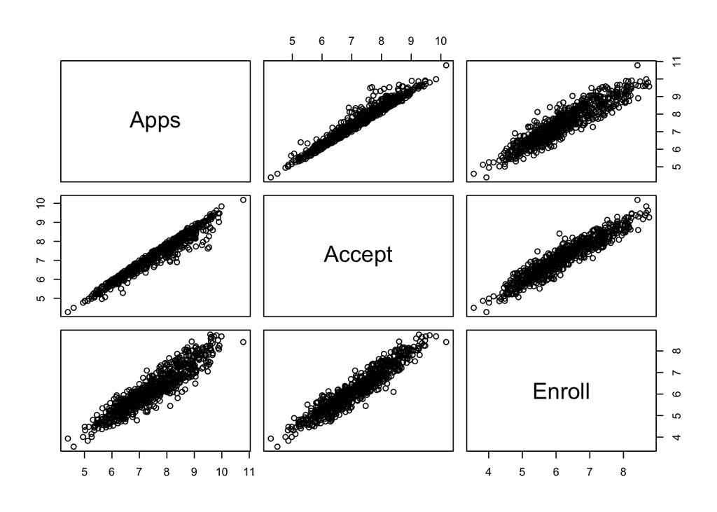

```r
pairs(log(College[,2:4]))
```

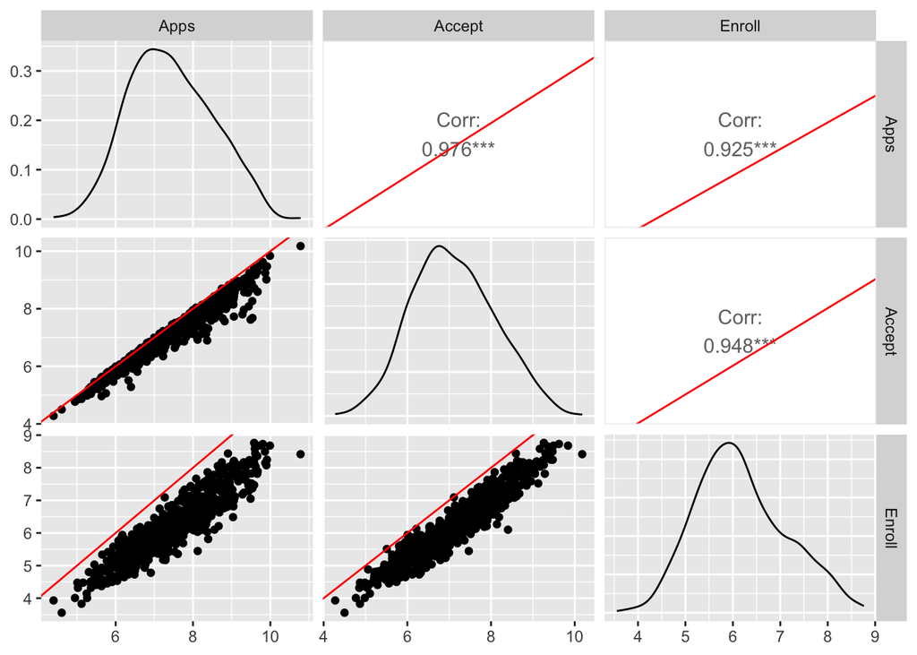

```r
GGally::ggpairs(log(College[,2:4])) + geom_abline(color = "red")
```

```r
# plots show high linear correlations which is to be expected as the variables are not independent,
# One can assume that Applications > Accept > Enroll.
```

3. Produce a graph with the boxplots for `Outstate` vs. `Private`and **interpret the plot**. (1)

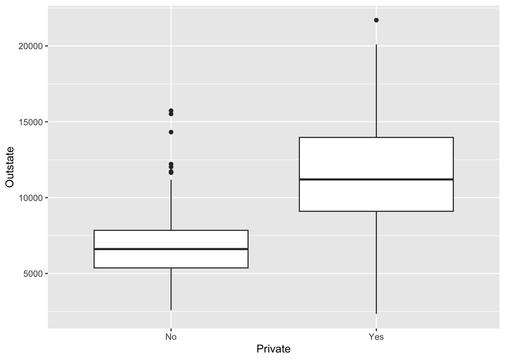

```r
ggplot(College, aes(Private, Outstate)) +
  geom_boxplot()
# Private schools have a much higher median for out of state students. This is expected
# as they do not have the financial incentives for in-state students generally present
# at public universities.
```

4. Create a new qualitative variable, `Elite` , by dividing the universities into two groups based on whether or not the proportion of students coming from the top $10\%$ of their high school classes is greater than $50\%$. (2)
- How many elite universities are there?
- Produce a set of boxplots for `Grad.Rate` versus `Elite` and **interpret the plot**.

```r
College$Elite <- College$Top10perc > 50
sum(College$Elite, na.rm = TRUE)
```

```
[1] 78
```

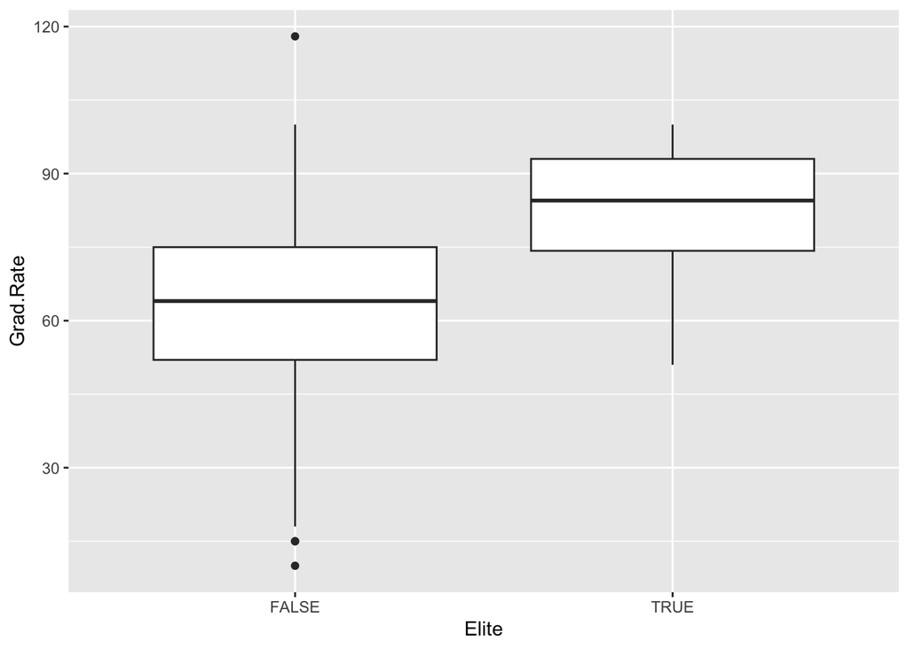

```r
#| layout-ncol: 1
ggplot(College, aes(Elite, Grad.Rate)) +
  geom_boxplot()
```

```r
# Elite schools have a much higher graduation rate. This would be expected since
# at least 50% of their students were highly successful in high school.
```

5. Use the `lm()` function to find a regression equation predicting the number of new students (`Enroll`) based on the graduation rate (`Grad.Rate`), qualifications of the faculty (`PhD`), and expenses for `Room.board` and `Books`. (3)
- Look at the output of `summary()`.
- Do you think this this model is flexible enough to fit the data. Why or Why Not? What would you recommend?
- (627 Only) Look at the output of `plot()`.
  - How do the results affect your previous answer and why?

```r
reg <- lm(Enroll ~ Grad.Rate + PhD + Room.Board + Books, data = College)
summary(reg)
```

```
Call:
lm(formula = Enroll ~ Grad.Rate + PhD + Room.Board + Books, data = College)

Residuals:
    Min      1Q  Median      3Q     Max
-1527.2  -491.3  -227.1   199.7  5093.5

Coefficients:
              Estimate Std. Error t value Pr(>|t|)
(Intercept) -410.91094  194.06281  -2.117 0.034544 *
Grad.Rate     -4.31626    2.01769  -2.139 0.032732 *
PhD           22.96001    2.03159  11.302  < 2e-16 ***
Room.Board    -0.13109    0.03213  -4.080 4.97e-05 ***
Books          0.68512    0.18802   3.644 0.000286 ***
---
Signif. codes:  0 '***' 0.001 '**' 0.01 '*' 0.05 '.' 0.1 ' ' 1

Residual standard error: 856.1 on 772 degrees of freedom
Multiple R-squared:  0.1555,    Adjusted R-squared:  0.1511
F-statistic: 35.53 on 4 and 772 DF,  p-value: < 2.2e-16
```

```r
# While the variables are significant, the adjusted R-squared is low suggesting
# a more flexible model could explain more of the variability.
# Add additional variables or try splines.
```

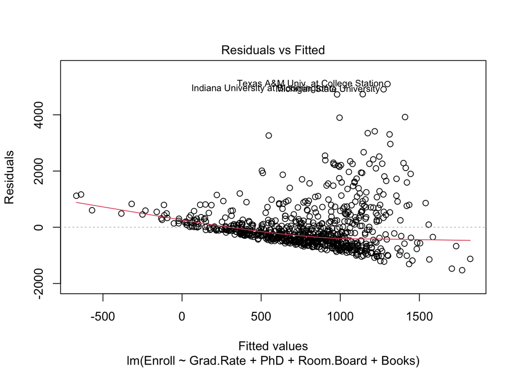

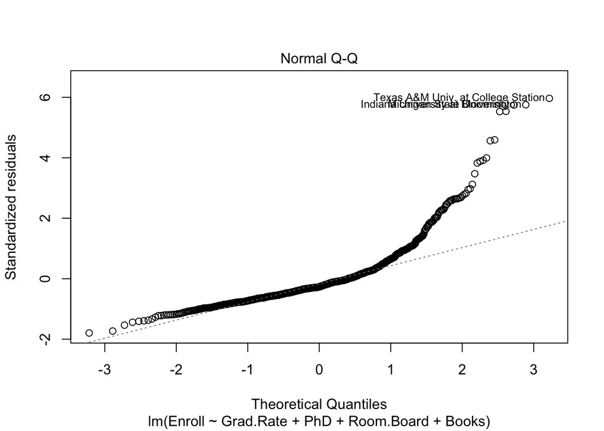

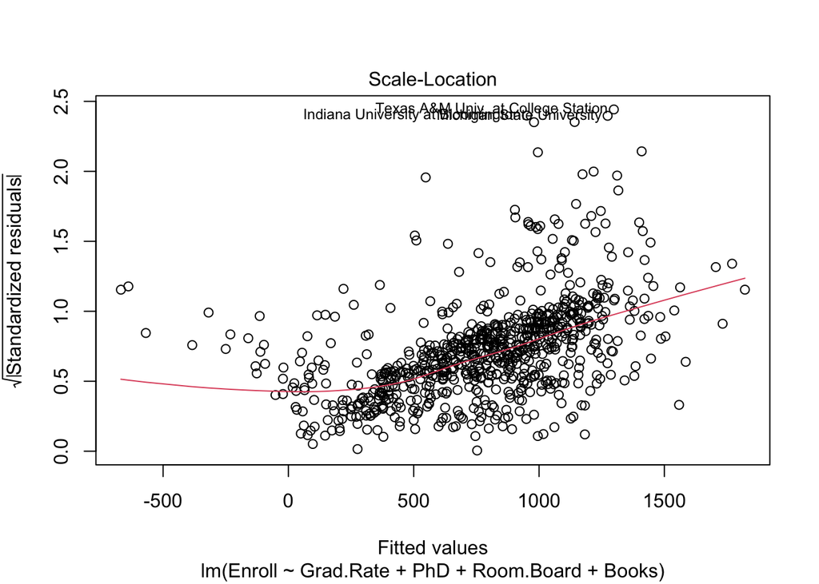

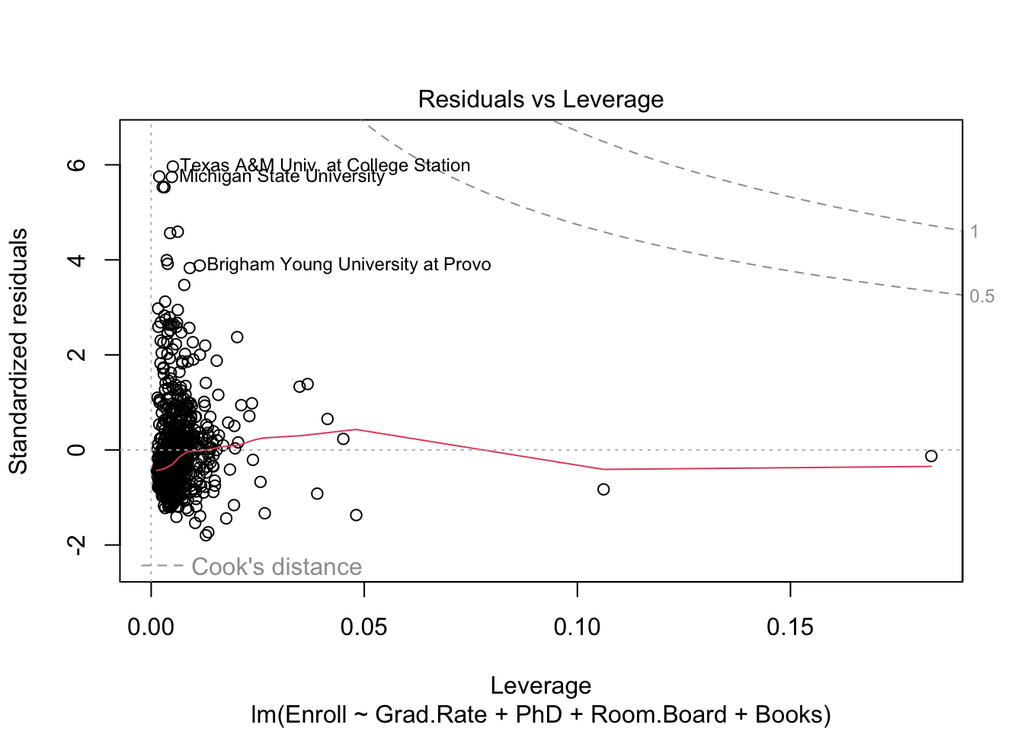

```r
plot(reg)
```

```r
# 627 Only
# The residuals vs Fitted plot shows a clear non-linearity suggesting the linear
# model is too restrictive.
```

## 0.6 Extra Credit (1 pt)

Watch [Quarto for the Curious](https://www.rstudio.com/conference/2022/talks/quarto-for-rmarkdown-users/) and answer the following questions.

1. How could Quarto make your ability to do, and communicate about, your data science work more efficient or effective?
2. Why or why not should we teach Quarto in DATA 412-612 along with RMarkdown?